# Peer-graded Assignment: Course Project 1

## Activity Monitoring Data

This assignment is about reading the Activity monitoring data from devices such as Fitbit, Nike, Fuelband etc from a monitoring device. The device records data at 5 minutes intervals throughout the day.

### Loading and Processing of Data

The below code is used to load and store the data in a variable and process/tranform it to make it suitable for the analysis.

```r
Activity_Data <- read.csv("activity.csv", header=TRUE, sep=",")
```

### What is mean total number of steps taken per day?

The below code calculates the total number of steps per day, plot a histogram and calculate/report mean and median of total number of steps taken per day

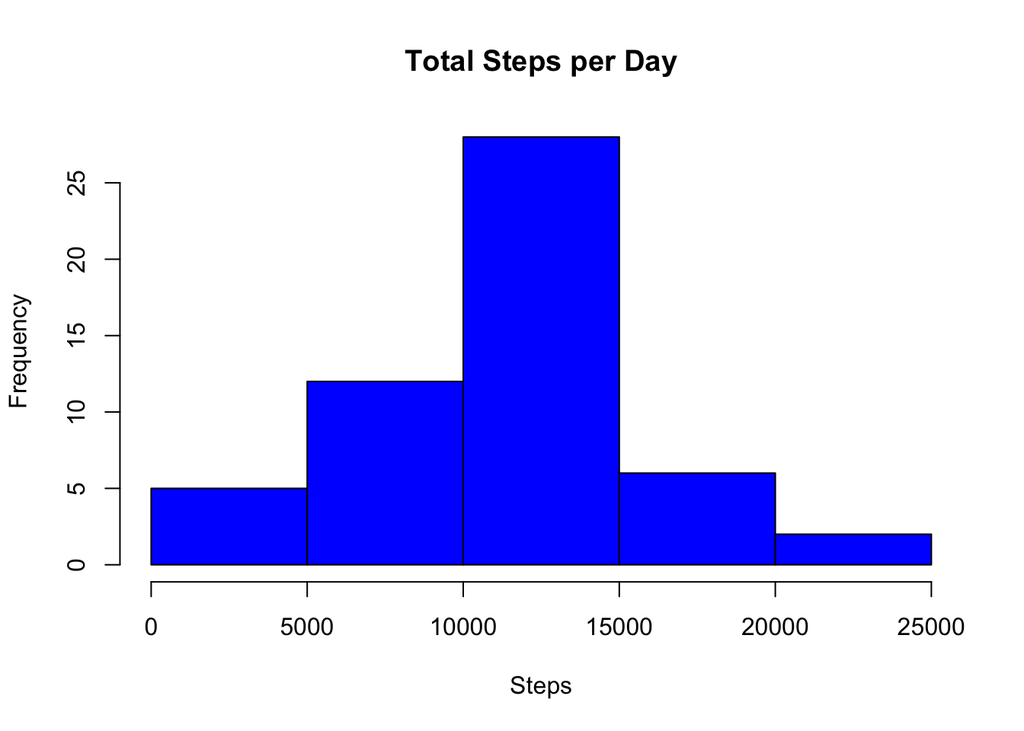

```r
Sum_Steps <- aggregate(steps ~ date, data = Activity_Data, sum, na.rm=TRUE)
hist(Sum_Steps$steps, col="blue", xlab="Steps", main="Total Steps per Day")
```

```r
mean(Sum_Steps$steps)
```

```
## [1] 10766.19
```

```r
median(Sum_Steps$steps)
```

```
## [1] 10765
```

### What is the average daily activity pattern?

The below code 1) makes a time series plot of the 5-minute interval(x-axis) and the average number of steps taken, averaged across all days and 2) Finds out Which 5-minute interval, on average across all the days in the dataset, contains the maximum number of steps?

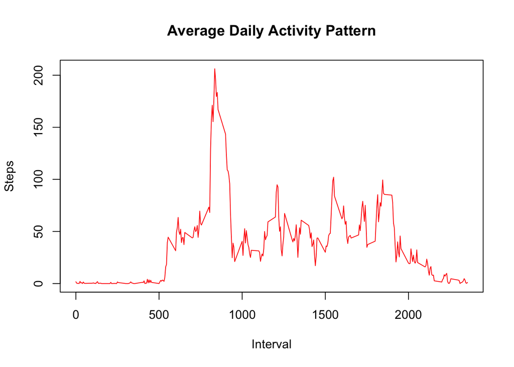

```r
Mean_Steps_Interval <- aggregate(steps ~ interval, data = Activity_Data, mean,na.rm=TRUE)
plot(Mean_Steps_Interval$interval, Mean_Steps_Interval$steps, type="l", col="red", xlab="Interval", ylab="Steps", main = "Average Daily Activity Pattern")
```

```r
Max_steps_Interval <- Mean_Steps_Interval[which.max(Mean_Steps_Interval$steps),]$interval
Max_steps_Interval
```

```
## [1] 835
```

### Imputing missing values

```r
Missing_Data <- sum(is.na(Activity_Data$steps))
Missing_Data
```

```
## [1] 2304
```

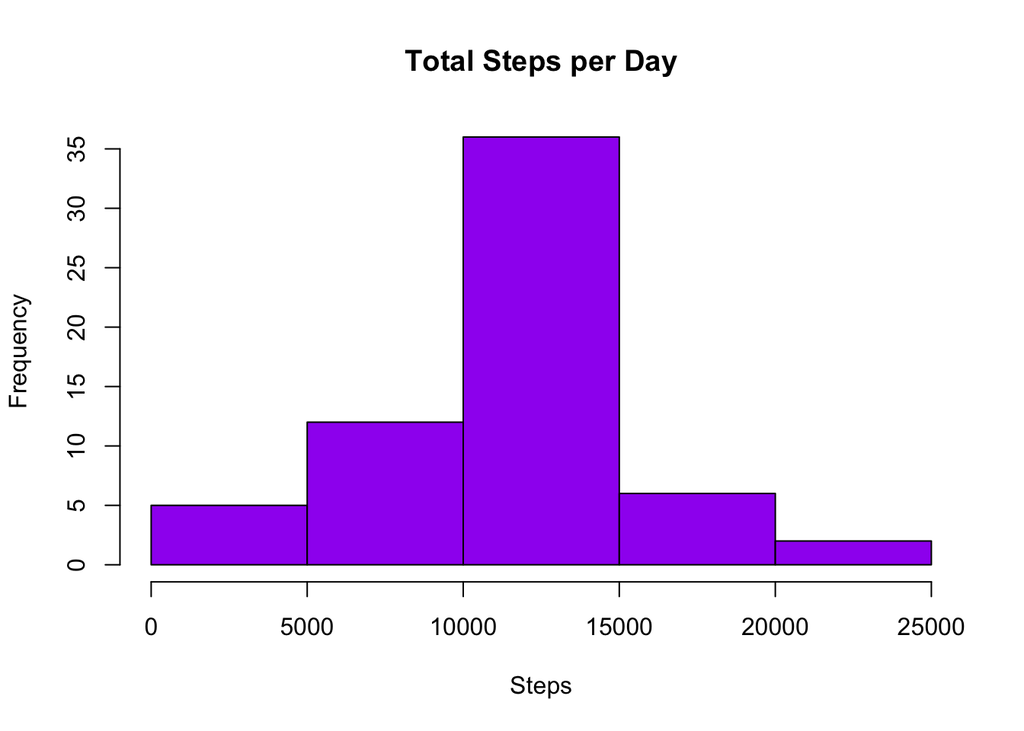

```r
Join_Values <- function(interval)
{
  Mean_Steps_Interval[Mean_Steps_Interval$interval == interval,]$steps
}
Activity_Data1 <- Activity_Data

for(i in 1:nrow(Activity_Data1))
{
  if(is.na(Activity_Data1$steps[i]))
  {

    Activity_Data1$steps[i] <- Join_Values(Activity_Data1$interval[i])

  }
}
Sum_Steps2 <- aggregate(steps ~ date, data = Activity_Data1, sum)
hist(Sum_Steps2$steps,col="purple", xlab="Steps", main="Total Steps per Day")
```

### Are there differences in activity patterns between weekdays and weekends?

1. Create a new factor variable in the dataset with two levels – “weekday” and “weekend” indicating whether a given date is a weekday or weekend day.
2. Make a panel plot containing a time series plot (i.e. 𝚝𝚢𝚙𝚎 = “𝚕”) of the 5-minute interval (x-axis) and the average number of steps taken, averaged across all weekday days or weekend days (y-axis). See the README file in the GitHub repository to see an example of what this plot should look like using simulated data.

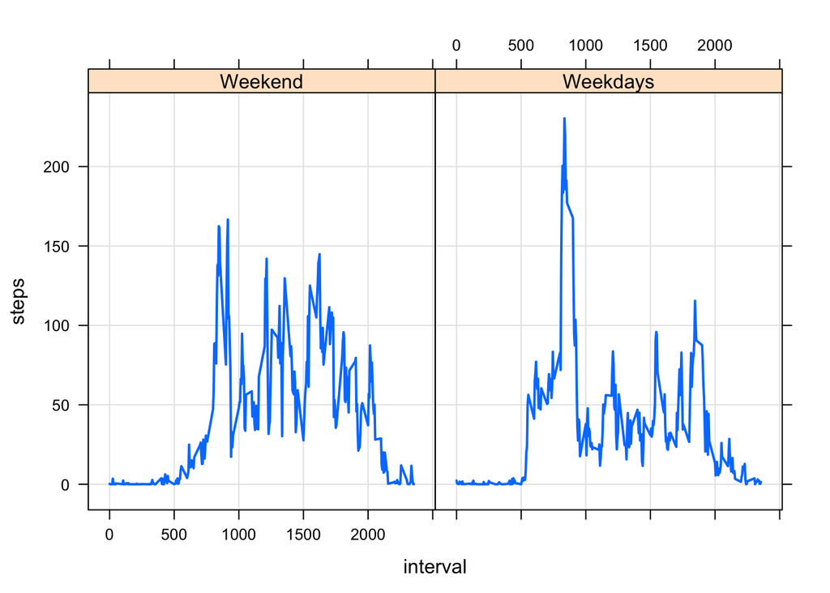

```r
library(lattice)
Activity_Data1$date <- as.Date(Activity_Data1$date)
week_days <- c('Monday', 'Tuesday', 'Wednesday', 'Thursday', 'Friday')
Activity_Data1$day <- factor(weekdays(Activity_Data1$date) %in% week_days, levels = c(FALSE, TRUE), labels=c("Weekend","Weekdays"))
Mean_Steps3 <- aggregate(steps ~ interval + day, data = Activity_Data1, mean)
xyplot(steps ~ interval | day, data = Mean_Steps3, type = "l", grid=TRUE, lwd=2)
```